# Lecture 16: Classification

PSTAT100: Data Science — Concepts and Analysis

John Inston

johninston@ucsb.edu

University of California, Santa Barbara

October 16, 2026

## 🚁 Overview

### Aims of the lecture

- Understand what **classification** is and how it differs from regression.
- Extend **logistic regression** from binary to multiclass problems.
- Introduce **decision trees**: how splits are chosen and trees are grown.
- Understand **random forests** as an ensemble that reduces variance.
- Evaluate and **compare all three classifiers** on a real credit scoring problem.

### 📚 Required Libraries

```python
import numpy as np
import pandas as pd
import matplotlib.pyplot as plt
import seaborn as sns
import re

from sklearn.linear_model import LogisticRegression
from sklearn.tree import DecisionTreeClassifier, plot_tree
from sklearn.ensemble import RandomForestClassifier
from sklearn.preprocessing import StandardScaler, OneHotEncoder
from sklearn.impute import SimpleImputer
from sklearn.pipeline import Pipeline
from sklearn.compose import ColumnTransformer
from sklearn.model_selection import train_test_split
from sklearn.metrics import (
    confusion_matrix, ConfusionMatrixDisplay,
    classification_report, accuracy_score,
    precision_recall_fscore_support,
)
```

### 💅 Figure Styles

```python
sns.set_style('whitegrid')
sns.set_palette('Set2')
```

# From Regression to Classification

## The Classification Problem

- In regression, the response is **continuous**: $Y \in \mathbb{R}$.
- In **classification**, the response is **categorical**: $Y \in \{1, 2, \ldots, K\}$.

### Some examples

| Task | Response classes |
| --- | --- |
| Email spam detection | Spam / Not Spam |
| Medical diagnosis | Disease / No Disease |
| Handwritten digit recognition | 0, 1, 2, …, 9 |
| **Credit scoring** | **Good / Standard / Poor** |

> The goal is to learn a **decision rule** $\hat{f}: \mathcal{X} \to \{1, \ldots, K\}$ that maps features to class labels as accurately as possible.

## Recap: Binary Logistic Regression (Lecture 13)

For a **binary** response $Y \in \{0, 1\}$, logistic regression models the probability of the positive class via the **sigmoid** function:

$$P(Y = 1 \mid \mathbf{x}) = \sigma(\mathbf{x}^\top \boldsymbol{\beta}) = \frac{1}{1 + e^{-\mathbf{x}^\top \boldsymbol{\beta}}}$$

The **decision rule** is simply:

$$\hat{y} = \begin{cases} 1 & \text{if } P(Y=1 \mid \mathbf{x}) \geq 0.5 \\ 0 & \text{otherwise} \end{cases}$$

This corresponds to a **linear decision boundary** $\mathbf{x}^\top\boldsymbol{\beta} = 0$ in feature space.

### Key properties

| Strength | Limitation |
| --- | --- |
| Interpretable coefficients | Assumes a **linear** boundary |
| Calibrated class probabilities | Struggles with interactions and non-linearity |
| Computationally efficient | Requires feature engineering for complex patterns |

## Extending to Multiple Classes

Binary logistic regression generalises to $K > 2$ classes in two main ways:

- **One-vs-Rest (OvR)**: fit $K$ separate binary classifiers, each asking “is this observation class $k$ or not?”. Predict the class whose classifier returns the highest probability.
- **Multinomial (softmax)**: fit all classes simultaneously using a single model:

$$P(Y = k \mid \mathbf{x}) = \frac{\exp(\mathbf{x}^\top \boldsymbol{\beta}_k)}{\displaystyle\sum_{j=1}^{K} \exp(\mathbf{x}^\top \boldsymbol{\beta}_j)}$$

> `sklearn`’s `LogisticRegression` uses the multinomial (softmax) approach by default when $K > 2$. The decision boundary remains **linear** — each class is still separated by a hyperplane.

## Why Go Beyond Logistic Regression?

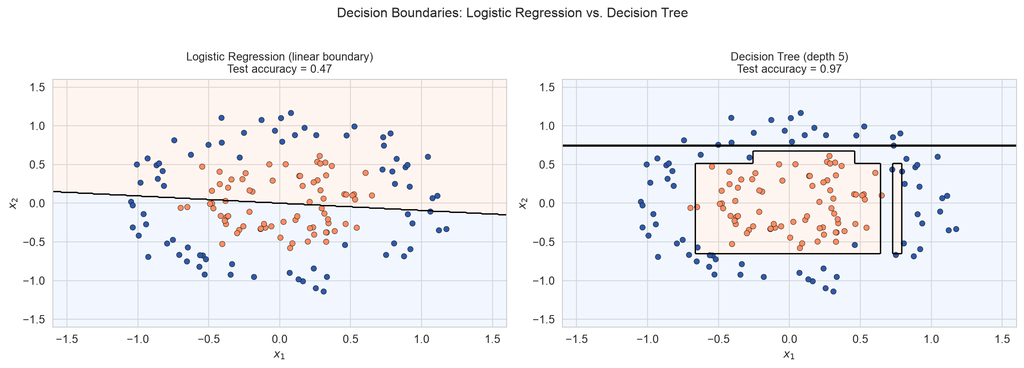

Two concentric circles cannot be separated by any straight line — logistic regression is structurally unable to solve this problem. A decision tree carves the space into axis-aligned rectangles and recovers the circular boundary well.

# Meet the Data

## 💳 The Credit Score Dataset

**Source**: Kaggle - Credit Score Classification dataset

### The business problem

- A bank wants to automatically assign each customer to a credit score band:
  - **Good** — low credit risk; eligible for favourable rates
  - **Standard** — moderate risk; standard products
  - **Poor** — high risk; restricted lending

### The data

- **100,000** labelled records across 8 months
- **27 raw features**: income, payment history, loan counts, credit utilisation, …
- Each customer appears in multiple monthly snapshots

## Loading the Data

### Training Data

- We download the file `train.csv` from Kaggle and load it into a DataFrame:

```python
raw = pd.read_csv('data/train.csv', low_memory=False)
```

- We print the shape of the data:

```python
print('Train Data Size : ',raw.shape)
```

```
Train Data Size :  (100000, 28)
```

- We also check the first few rows to get a sense of the data:

```python
raw.head()
```

## Loading the Data

|  | ID | Customer_ID | Month | Name | Age | SSN | Occupation | Annual_Income | Monthly_Inhand_Salary | Num_Bank_Accounts | ... | Credit_Mix | Outstanding_Debt | Credit_Utilization_Ratio | Credit_History_Age | Payment_of_Min_Amount | Total_EMI_per_month | Amount_invested_monthly | Payment_Behaviour | Monthly_Balance | Credit_Score |
| --- | --- | --- | --- | --- | --- | --- | --- | --- | --- | --- | --- | --- | --- | --- | --- | --- | --- | --- | --- | --- | --- |
| 0 | 0x1602 | CUS_0xd40 | January | Aaron Maashoh | 23 | 821-00-0265 | Scientist | 19114.12 | 1824.843333 | 3 | ... | _ | 809.98 | 26.822620 | 22 Years and 1 Months | No | 49.574949 | 80.41529543900253 | High_spent_Small_value_payments | 312.49408867943663 | Good |
| 1 | 0x1603 | CUS_0xd40 | February | Aaron Maashoh | 23 | 821-00-0265 | Scientist | 19114.12 | NaN | 3 | ... | Good | 809.98 | 31.944960 | NaN | No | 49.574949 | 118.28022162236736 | Low_spent_Large_value_payments | 284.62916249607184 | Good |
| 2 | 0x1604 | CUS_0xd40 | March | Aaron Maashoh | -500 | 821-00-0265 | Scientist | 19114.12 | NaN | 3 | ... | Good | 809.98 | 28.609352 | 22 Years and 3 Months | No | 49.574949 | 81.699521264648 | Low_spent_Medium_value_payments | 331.2098628537912 | Good |
| 3 | 0x1605 | CUS_0xd40 | April | Aaron Maashoh | 23 | 821-00-0265 | Scientist | 19114.12 | NaN | 3 | ... | Good | 809.98 | 31.377862 | 22 Years and 4 Months | No | 49.574949 | 199.4580743910713 | Low_spent_Small_value_payments | 223.45130972736786 | Good |
| 4 | 0x1606 | CUS_0xd40 | May | Aaron Maashoh | 23 | 821-00-0265 | Scientist | 19114.12 | 1824.843333 | 3 | ... | Good | 809.98 | 24.797347 | 22 Years and 5 Months | No | 49.574949 | 41.420153086217326 | High_spent_Medium_value_payments | 341.48923103222177 | Good |

5 rows × 28 columns

## A First Look at the Features

```python
raw.info()
```

```
<class 'pandas.DataFrame'>
RangeIndex: 100000 entries, 0 to 99999
Data columns (total 28 columns):
 #   Column                    Non-Null Count   Dtype
---  ------                    --------------   -----
 0   ID                        100000 non-null  str
 1   Customer_ID               100000 non-null  str
 2   Month                     100000 non-null  str
 3   Name                      90015 non-null   str
 4   Age                       100000 non-null  str
 5   SSN                       100000 non-null  str
 6   Occupation                100000 non-null  str
 7   Annual_Income             100000 non-null  str
 8   Monthly_Inhand_Salary     84998 non-null   float64
 9   Num_Bank_Accounts         100000 non-null  int64
```

[output cut: 20 more lines]

- Several numeric columns are stored as **strings** with dirty values (`_`, trailing letters, embedded underscores).
- Data is **missing** in many columns, but not with a consistent placeholder.
- Cleaning is needed before any modelling.

## Data Cleaning

The raw data required several steps before modelling:

- **Dropped identifier and sensitive columns**: `ID`, `Customer_ID`, `Name`, `SSN`, `Type_of_Loan`
- **Coerced dirty numeric strings**: stripped embedded underscores and trailing characters from 8 columns
- **Parsed credit history age**: `"22 Years and 1 Months"` → integer months (`Credit_History_Months`)
- **Replaced `_` placeholder** with `NaN` in `Credit_Mix`

```python
print(f"Raw: {raw.shape} -> Cleaned: {df.shape}")
print(f"\nMissing values after cleaning:")
missing = df.isnull().sum()
print(
    missing[missing > 0]
    .sort_values(ascending=False)
    .to_string()
)
```

```
Raw: (100000, 28) -> Cleaned: (100000, 23)

Missing values after cleaning:
Credit_Mix                 20195
Monthly_Inhand_Salary      15002
Credit_History_Months       9030
Num_of_Delayed_Payment      7002
Amount_invested_monthly     4479
Changed_Credit_Limit        2091
Num_Credit_Inquiries        1965
Monthly_Balance             1200
```

## Target Distribution

- **Standard** is the majority class (~53 %), **Good** is the rarest (~18 %) — the dataset is moderately imbalanced.
- This means a naive classifier predicting “Standard” every time would achieve ~53 % accuracy — our models must do meaningfully better.

```python
fig, ax = plt.subplots(figsize=(7, 4))
sns.countplot(data=df, x='Credit_Score', ax=ax)

n = len(df)
for bar in ax.patches:
    pct = bar.get_height() / n * 100
    ax.text(bar.get_x() + bar.get_width() / 2,
            bar.get_height() + 400,
            f'{pct:.1f} %', ha='center', fontsize=10)

ax.set_xlabel('Credit Score Band')
ax.set_ylabel('Count')
ax.set_title('Credit Score Class Distribution')
plt.tight_layout()
plt.show()
```

## Target Distribution

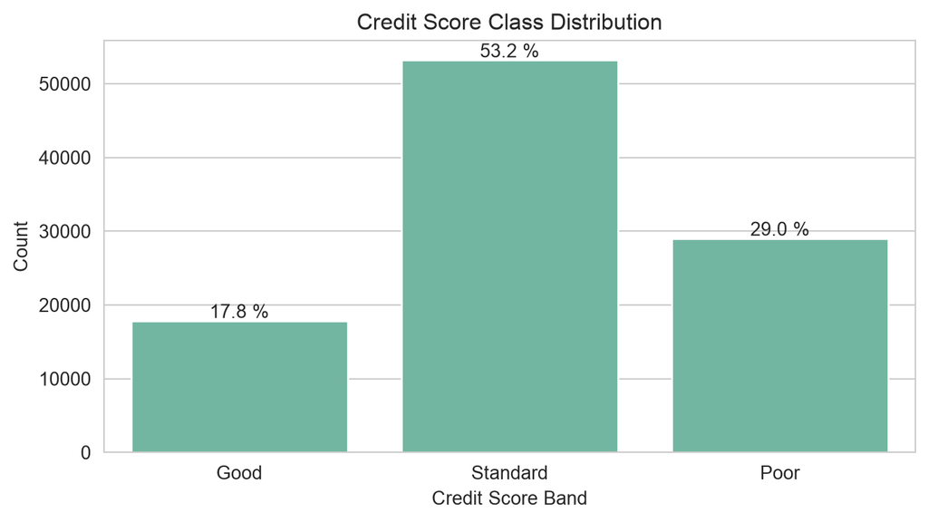

Credit score class distribution. Standard is the majority class (53 %); Good is the rarest (18 %). Imbalance will matter for evaluation.

## Building the Feature Matrix

- We select **17 numeric** and **5 categorical** features, encode the target as an integer, then perform an **80/20 stratified train/validation split** — keeping **class proportions equal in both sets**.
  - We use the function `train_test_split` from `sklearn.model_selection` with `stratify=y`.

```python
num_features = [
    'Age', 'Annual_Income', 'Monthly_Inhand_Salary', 'Num_Bank_Accounts',
    'Num_Credit_Card', 'Interest_Rate','Num_of_Loan', 'Delay_from_due_date',
    'Num_of_Delayed_Payment', 'Changed_Credit_Limit', 'Num_Credit_Inquiries',
    'Outstanding_Debt', 'Credit_Utilization_Ratio', 'Credit_History_Months',
    'Total_EMI_per_month', 'Amount_invested_monthly', 'Monthly_Balance',
]
cat_features = [
    'Month', 'Occupation', 'Credit_Mix',
    'Payment_of_Min_Amount', 'Payment_Behaviour',
]
# Encode target: Poor=0, Standard=1, Good=2
label_map = {'Poor': 0, 'Standard': 1, 'Good': 2}
y = df['Credit_Score'].map(label_map).values
X = df[num_features + cat_features]

X_train, X_val, y_train, y_val = train_test_split(
    X, y, test_size=0.2, stratify=y, random_state=42
)
print(f"Train: {X_train.shape[0]:,}")
print(f"Validation: {X_val.shape[0]:,}")
```

```
Train: 80,000
Validation: 20,000
```

## Preprocessing Pipeline

- Numeric features are **median-imputed** then **standardised**; categorical features are **mode-imputed** then **one-hot (dummy) encoded**.
- The preprocessor is **fitted on the training set only** and then applied to the validation set — preventing any **data leakage** - *where information from the validation set influences the training process*.

```python
num_pipe = Pipeline([
    ('impute', SimpleImputer(strategy='median')),
    ('scale',  StandardScaler()),
])
cat_pipe = Pipeline([
    ('impute', SimpleImputer(strategy='most_frequent')),
    ('encode', OneHotEncoder(handle_unknown='ignore', sparse_output=False)),
])
preprocessor = ColumnTransformer([
    ('num', num_pipe, num_features),
    ('cat', cat_pipe, cat_features),
])

X_train_p = preprocessor.fit_transform(X_train)
X_val_p   = preprocessor.transform(X_val)

ohe_cols     = (preprocessor.named_transformers_['cat']['encode']
                .get_feature_names_out(cat_features).tolist())
feature_names = num_features + ohe_cols
print(f"Processed feature matrix: {X_train_p.shape}")
```

```
Processed feature matrix: (80000, 54)
```

# Evaluating Classifiers

## Choosing an Evaluation Metric

**Accuracy** — the simplest metric: fraction of all predictions that are correct.

$$\text{Accuracy} = \frac{\text{Number correct}}{\text{Total predictions}}$$

**But accuracy can be misleading.** In our dataset, 53 % of customers are “Standard” — a classifier that always predicts “Standard” scores 53 % accuracy without learning anything useful.

For each class $k$ we also compute:

- **Precision** - Of all customers we predicted as $k$, what fraction truly are $k$?
- **Recall** - Of all customers that truly are $k$, what fraction did we identify?
- **F1** - Harmonic mean of precision and recall — balances the two.

> When classes are **imbalanced**, a model can game accuracy by favouring the majority class. Precision and recall expose this — they measure performance *within* each class separately.

## Beyond Accuracy: The Confusion Matrix

**Confusion Matrix**

For $K$ classes, a $K \times K$ table where entry $(i, j)$ is the number of observations of **true class $i$** predicted as **class $j$**.

- **Diagonal** entries: correct predictions.
- **Off-diagonal** entries: misclassifications.

For our credit score problem ($K = 3$):

|  | Predicted Poor | Predicted Standard | Predicted Good |
| --- | --- | --- | --- |
| **True Poor** | TP | FN | FN |
| **True Standard** | FP | TP | FN |
| **True Good** | FP | FP | TP |

## Precision, Recall, and F1-Score

For each class $k$, treating it as “positive” vs. “all others”:

$$\text{Precision}_k = \frac{TP_k}{TP_k + FP_k} \qquad \text{Recall}_k = \frac{TP_k}{TP_k + FN_k}$$

$$F_{1,k} = \frac{2 \cdot \text{Precision}_k \cdot \text{Recall}_k}{\text{Precision}_k + \text{Recall}_k}$$

- **Precision**: of all customers *predicted* as class $k$, what fraction truly belong to $k$? High precision means few false alarms.
- **Recall**: of all customers who *truly* belong to class $k$, what fraction did we correctly identify? High recall means few missed cases.
- **F1**: the harmonic mean of precision and recall — useful when you care about both equally, and penalises extreme imbalances between the two.

> In credit scoring, **recall for “Poor”** is critical — a missed high-risk customer can be very costly. But **precision** also matters — falsely flagging a “Good” customer harms trust.

## Aggregating Across Classes

- Precision, recall, and F1 are defined **per class**, but we often want a **single number** to compare models. We aggregate across classes in different ways depending on how much we care about each one.

| Strategy | How |
| --- | --- |
| **Macro average** | Unweighted mean across all $K$ classes |
| **Weighted average** | Mean weighted by class support (# true samples) |
| **Micro average** | Pool TP/FP/FN across all classes first, then compute |

> **Weighted average** is usually most informative when class sizes differ — as they do here (Good is the rarest band).

# Logistic Regression in Practice

## Fitting a Logistic Regression

- We fit a **multinomial logistic regression** on the preprocessed training data; `max_iter=1000` ensures convergence.
- The model is then used to predict the validation set, with overall accuracy printed as a quick baseline check.

```python
lr = LogisticRegression(
    max_iter=1000,    # multinomial is the default for 3+ classes in sklearn ≥ 1.5
    random_state=42,
)
lr.fit(X_train_p, y_train)

y_pred_lr = lr.predict(X_val_p)
print(f"Validation accuracy: {accuracy_score(y_val, y_pred_lr):.4f}")
```

```
Validation accuracy: 0.6162
```

## Evaluating Logistic Regression

- `classification_report` prints **per-class precision, recall, and F1** alongside macro and weighted averages.
- This gives a richer picture than accuracy alone — especially important given the class imbalance (Good ≈ 18 %, Standard ≈ 53 %).

```python
print(classification_report(
    y_val, y_pred_lr,
    target_names=['Poor', 'Standard', 'Good'],
))
```

```
              precision    recall  f1-score   support

        Poor       0.63      0.43      0.51      5799
    Standard       0.64      0.73      0.69     10635
        Good       0.52      0.57      0.54      3566

    accuracy                           0.62     20000
   macro avg       0.60      0.58      0.58     20000
weighted avg       0.62      0.62      0.61     20000
```

## Confusion Matrix — Logistic Regression

- We produce the confusion matrix which summarizes the counts of true vs. predicted classes.

```python
fig, ax = plt.subplots(figsize=(6, 5))
ConfusionMatrixDisplay(
    confusion_matrix(y_val, y_pred_lr),
    display_labels=['Poor', 'Standard', 'Good'],
).plot(ax=ax, colorbar=False, cmap='Oranges')
ax.set_title('Logistic Regression — Confusion Matrix', fontsize=11)
plt.tight_layout()
plt.show()
```

## Confusion Matrix — Logistic Regression

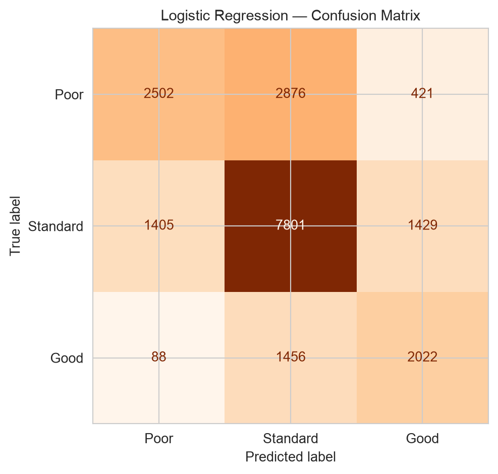

# Decision Trees

## 🌳 What is a Decision Tree?

A **decision tree** partitions the feature space into **rectangular regions** using a recursive sequence of binary splits. Each leaf is assigned the **majority class** of training observations that land there.

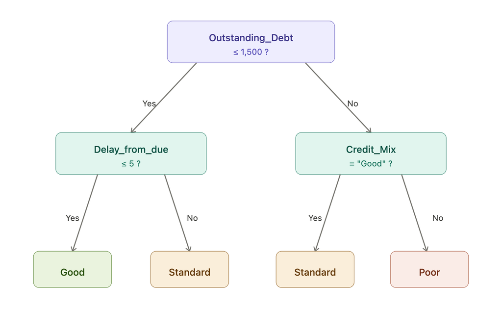

Decision Tree Visualization.

> Decision trees are **fully non-parametric** — no distributional assumption about the boundary shape. The tree structure *is* the model.

## How Splits are Chosen: Gini Impurity

At each node we search for the feature $j$ and threshold $t$ that **most reduce impurity** in the resulting child nodes.

**Gini Impurity**

For a node containing observations with class proportions $p_1, \ldots, p_K$:

$$G = 1 - \sum_{k=1}^{K} p_k^2$$

$G = 0$ means the node is **pure** (all one class). $G$ is maximised when classes are equally represented.

The **Gini gain** of a candidate split is:

$$\Delta G = G(\text{parent}) - \frac{n_L}{n}\,G(\text{left}) - \frac{n_R}{n}\,G(\text{right})$$

We choose $(j^*, t^*)$ that **maximises** $\Delta G$.

## Gini Impurity — Visualized

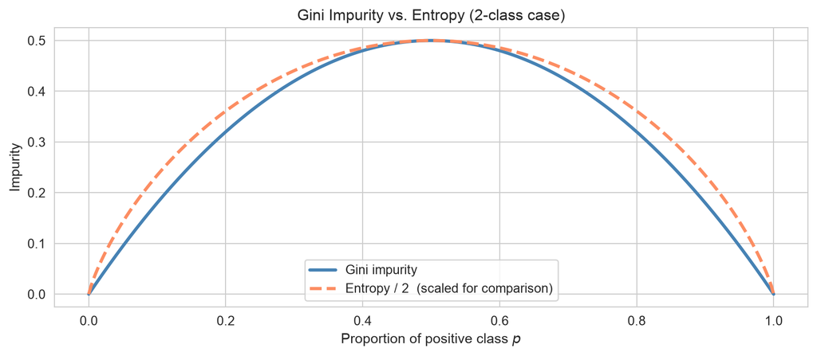

Gini impurity and (scaled) entropy as a function of the positive-class proportion in a 2-class problem. Both criteria are maximised at p = 0.5 and zero at pure nodes.

## Growing and Stopping a Tree

A decision tree is grown **recursively**:

1. Find the best split $(j^*, t^*)$ at the current node.
2. Partition observations into left ($x_{j^*} \leq t^*$) and right ($x_{j^*} > t^*$) children.
3. Recurse on each child.
4. **Stop** when a stopping criterion is met.

### Stopping criteria

| Parameter | Effect |
| --- | --- |
| `max_depth` | Hard cap on tree height |
| `min_samples_split` | Minimum observations needed to attempt a split |
| `min_samples_leaf` | Minimum observations required in each resulting leaf |
| `min_impurity_decrease` | Only split if $\Delta G$ exceeds this threshold |

## Overfitting with Decision Trees

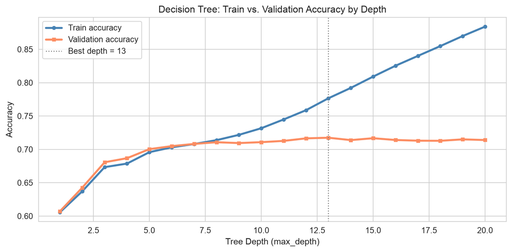

Train and validation accuracy as a function of max_depth. Shallow trees underfit; very deep trees memorise the training set and generalise poorly.

## Post-Pruning: Cost-Complexity

The stopping criteria above are **pre-pruning** controls — they prevent the tree from growing too large in the first place.

**Post-pruning** takes the opposite approach: grow the full tree first, then *cut back* branches whose impurity reduction is outweighed by the cost of keeping them.

**Cost-Complexity Criterion**

For a subtree $T$ with $|T|$ leaves, define the penalised training cost:

$$R_\alpha(T) = R(T) + \alpha \cdot |T|$$

where $R(T)$ is the weighted leaf impurity and $\alpha \geq 0$ is the **complexity parameter**.

| Value of $\alpha$ | Effect |
| --- | --- |
| $\alpha = 0$ | No penalty — the full, unpruned tree is returned |
| $\alpha$ small | Only the weakest branches are removed |
| $\alpha$ large | Heavy pruning; tree shrinks toward a single node |

The **optimal $\alpha$** is chosen by evaluating held-out performance across the pruning path.

## Choosing $\alpha$ by Validation

- `cost_complexity_pruning_path` returns every $\alpha$ at which a branch would be pruned; we evaluate validation accuracy across this path and select the best value.

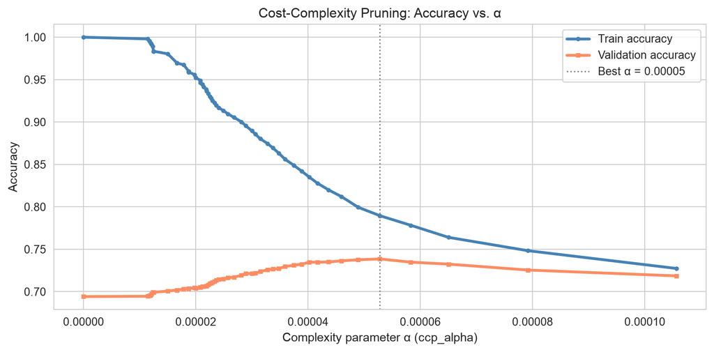

Validation accuracy peaks at an intermediate α — just enough pruning to improve generalisation without discarding useful splits.

# Decision Trees in Practice

## Fitting Our First Decision Tree

- To fit our decision tree we use `sklearn.tree.DecisionTreeClassifier` with `max_depth=8` and `min_samples_leaf=50` to prevent overfitting.
- We then predict the validation set and print the accuracy as a quick check.

```python
dt = DecisionTreeClassifier(
    max_depth=8,
    min_samples_leaf=50,
    random_state=42,
)
dt.fit(X_train_p, y_train)

y_pred_dt = dt.predict(X_val_p)
print(f"Validation accuracy: {accuracy_score(y_val, y_pred_dt):.4f}")
```

```
Validation accuracy: 0.7085
```

## Visualizing the Top of the Tree

- We produce a visualization of the top 3 levels of the tree using `sklearn.tree.plot_tree`.
  - Each node displays the splitting feature, Gini impurity, sample count, and class distribution.
  - Leaf colours indicate the predicted class.

```python
fig, ax = plt.subplots(figsize=(14, 5))
plot_tree(
    dt,
    max_depth=3,
    feature_names=feature_names,
    class_names=['Poor', 'Standard', 'Good'],
    filled=True,
    rounded=True,
    fontsize=7,
    ax=ax,
)
ax.set_title('Decision Tree — Top 3 Levels', fontsize=12)
plt.tight_layout()
plt.show()
```

## Visualizing the Top of the Tree

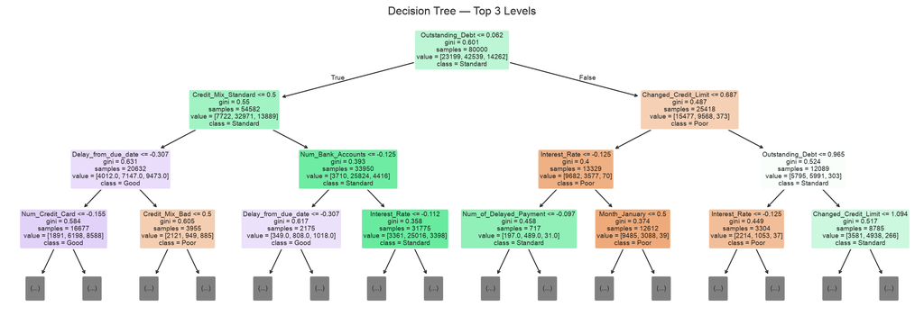

The first three levels of the decision tree. Each node shows the splitting feature, Gini impurity, sample count, and class distribution. Leaf colours indicate the predicted class.

## Evaluating the Decision Tree

- To evaluate the decision tree, we print the classification report which includes precision, recall, and F1-score for each class, as well as macro and weighted averages.

```python
print(classification_report(
    y_val, y_pred_dt,
    target_names=['Poor', 'Standard', 'Good'],
))
```

```
              precision    recall  f1-score   support

        Poor       0.72      0.69      0.70      5799
    Standard       0.75      0.74      0.75     10635
        Good       0.58      0.65      0.61      3566

    accuracy                           0.71     20000
   macro avg       0.68      0.69      0.69     20000
weighted avg       0.71      0.71      0.71     20000
```

## Confusion Matrix — Decision Tree

- Finally we plot the confusion matrix for the decision tree predictions on the validation set, which shows the counts of true vs. predicted classes.

```python
fig, ax = plt.subplots(figsize=(6, 5))
ConfusionMatrixDisplay(
    confusion_matrix(y_val, y_pred_dt),
    display_labels=['Poor', 'Standard', 'Good'],
).plot(ax=ax, colorbar=False, cmap='Blues')
ax.set_title('Decision Tree — Confusion Matrix', fontsize=11)
plt.tight_layout()
plt.show()
```

## Confusion Matrix — Decision Tree

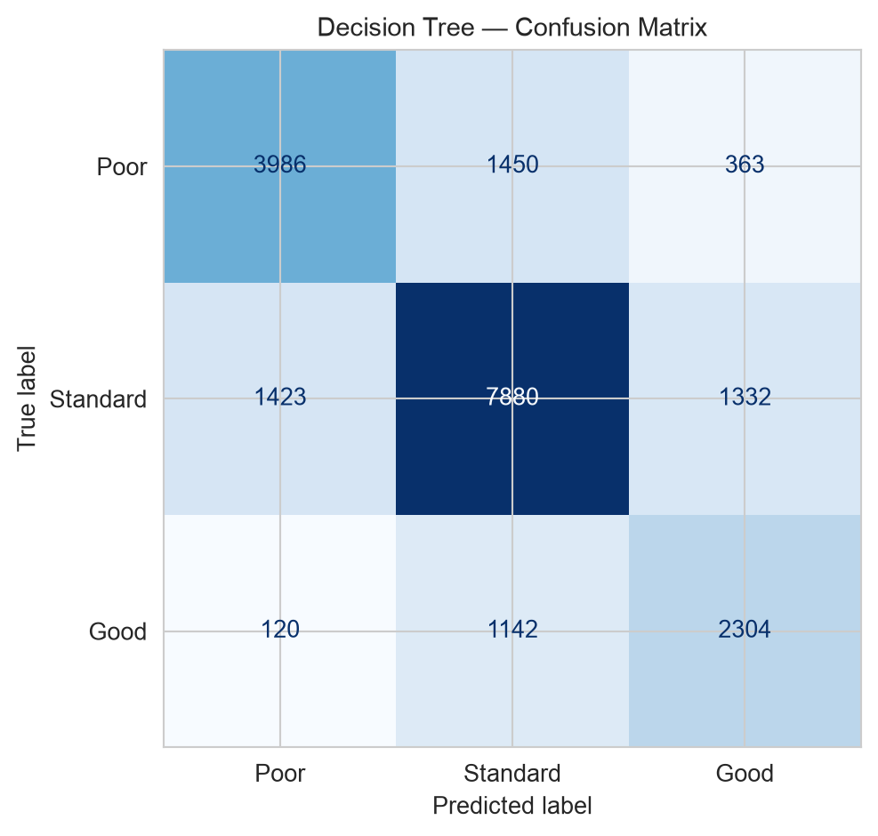

Confusion matrix for the decision tree (validation set). Rows are true labels; columns are predicted labels.

# From Trees to Forests

## 🌲 The Variance Problem with Single Trees

Decision trees have **high variance**: small changes in the training data can produce very different trees.

### Why?

- Each split depends entirely on which observations happened to be in the training set.
- A single influential observation can **redirect an entire branch**.
- **Deep trees memorise noise** rather than signal.

> Can we reduce variance **without** substantially increasing bias?

## Bagging: Bootstrap Aggregating

**Idea**: train many trees on **different bootstrap samples** of the training data, then combine their predictions by majority vote.

**Bagging Algorithm**

For $b = 1, \ldots, B$:

1. Draw a **bootstrap sample** $\mathcal{D}^*_b$ of size $n$ from the training data (sampling *with* replacement).
2. Fit a full, unpruned decision tree $T_b$ on $\mathcal{D}^*_b$.

**Prediction**: $\hat{y} = \text{mode}\!\left\{T_1(\mathbf{x}), \ldots, T_B(\mathbf{x})\right\}$.

- Each tree sees $\approx 63\%$ of observations; the rest form a natural **out-of-bag (OOB)** validation set.
- Averaging over $B$ trees reduces variance by a factor of $\approx B$ — *provided trees are uncorrelated*.

## Random Forests: Decorrelating the Trees

**The problem with plain bagging**: if one feature is very strong, all trees split on it first → trees are correlated → variance reduction is limited.

**Random Forest**

Bagging + **feature subsampling**: at each candidate split, consider only a **random subset of $m$ features** (default: $m = \lfloor\sqrt{p}\rfloor$) rather than all $p$.

- Decorrelates trees → greater variance reduction than plain bagging.
- Slight bias increase (fewer features considered per split), but usually a net improvement.
- The OOB observations give a **free internal accuracy estimate** — no separate validation set needed.

## Feature Importance from Random Forests

Random forests provide a natural **variable importance** measure:

**Mean Decrease in Impurity (MDI)**

For feature $j$, sum the weighted Gini gain from every split on $j$ across all trees:

$$\text{Importance}(j) = \frac{1}{B}\sum_{b=1}^{B} \sum_{\substack{v \in T_b \\ \text{split on } j}} \frac{n_v}{n}\,\Delta G_v$$

Features with large, frequent Gini gains are ranked most important.

> **Caveat**: MDI can overstate importance for high-cardinality or continuous features. Permutation importance is a more reliable alternative for such cases.

# Random Forests in Practice

## Fitting a Random Forest

- We fit a random forest using `sklearn.ensemble.RandomForestClassifier` with 200 trees, `max_features='sqrt'`, and `min_samples_leaf=10` to prevent overfitting.
- We also set `oob_score=True` to compute the out-of-bag accuracy, which provides an internal validation estimate without needing a separate validation set.

```python
rf = RandomForestClassifier(
    n_estimators=200,       # 200 trees in the ensemble
    max_features='sqrt',    # √p features considered per split
    min_samples_leaf=10,
    n_jobs=-1,              # parallelise across all CPU cores
    oob_score=True,         # compute out-of-bag accuracy
    random_state=42,
)
rf.fit(X_train_p, y_train)

y_pred_rf = rf.predict(X_val_p)
print(f"OOB accuracy:        {rf.oob_score_:.4f}")
print(f"Validation accuracy: {accuracy_score(y_val, y_pred_rf):.4f}")
```

```
OOB accuracy:        0.7467
Validation accuracy: 0.7510
```

## Evaluating the Random Forest

- To evaluate the random forest, we print the classification report which includes precision, recall, and F1-score for each class, as well as macro and weighted averages.

```python
print(classification_report(
    y_val, y_pred_rf,
    target_names=['Poor', 'Standard', 'Good'],
))
```

## Evaluating the Random Forest

```
              precision    recall  f1-score   support

        Poor       0.77      0.73      0.74      5799
    Standard       0.78      0.79      0.78     10635
        Good       0.65      0.68      0.67      3566

    accuracy                           0.75     20000
   macro avg       0.73      0.73      0.73     20000
weighted avg       0.75      0.75      0.75     20000
```

## Confusion Matrix — Random Forest

- We produce the confusion matrix for the random forest predictions on the validation set, which shows the counts of true vs. predicted classes.

```python
fig, ax = plt.subplots(figsize=(6, 5))
ConfusionMatrixDisplay(
    confusion_matrix(y_val, y_pred_rf),
    display_labels=['Poor', 'Standard', 'Good'],
).plot(ax=ax, colorbar=False, cmap='Greens')
ax.set_title('Random Forest — Confusion Matrix', fontsize=11)
plt.tight_layout()
plt.show()
```

## Confusion Matrix — Random Forest

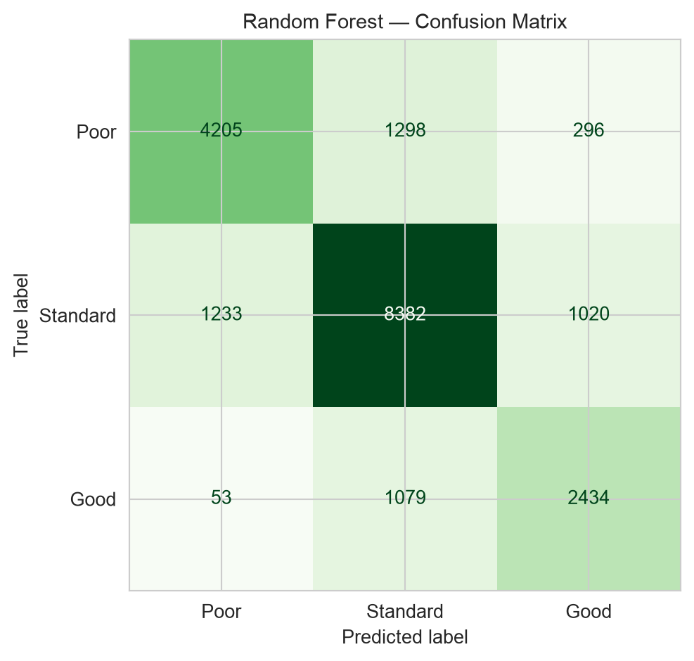

Confusion matrix for the random forest (validation set). Compare the off-diagonal entries with the decision tree.

## Feature Importance Plot

- The following code produces a horizontal bar plot of the top 15 most important features according to mean decrease in Gini impurity.
- The features at the top produce the largest, most frequent gains across all 200 trees in the random forest.

```python
importances = pd.Series(rf.feature_importances_, index=feature_names)
top15 = importances.sort_values(ascending=False).head(15)

fig, ax = plt.subplots(figsize=(9, 5))
top15.sort_values().plot.barh(ax=ax, color='steelblue', edgecolor='white')
ax.set_xlabel('Mean Decrease in Impurity', fontsize=11)
ax.set_title('Random Forest — Top 15 Feature Importances', fontsize=12)
plt.tight_layout()
plt.show()
```

## Feature Importance Plot

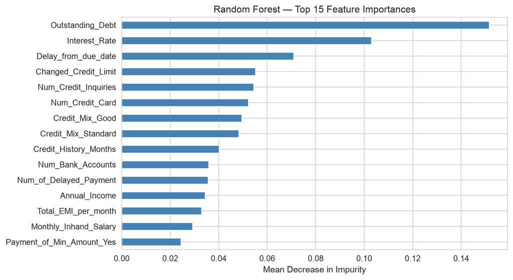

Top 15 most important features by mean decrease in Gini impurity. Features at the top produce the largest, most frequent gains across all 200 trees.

## Comparing All Three Classifiers

- To compare the three classifiers head-to-head, we compute per-class precision, recall, and F1 for each model and visualise them side by side in a grouped bar chart.

```python
classes = ['Poor', 'Standard', 'Good']

results = {}
for name, pred in [('Logistic Reg.', y_pred_lr),
                   ('Decision Tree', y_pred_dt),
                   ('Random Forest', y_pred_rf)]:
    p, r, f, _ = precision_recall_fscore_support(
        y_val, pred, labels=[0, 1, 2])
    results[name] = pd.DataFrame(
        {'Class': classes, 'Precision': p, 'Recall': r, 'F1': f})

combined = (
    pd.concat(results, names=['Model'])
    .reset_index(level=0)
    .rename(columns={'level_0': 'Model'})
)
melted = combined.melt(
    id_vars=['Model', 'Class'],
    value_vars=['Precision', 'Recall', 'F1'],
    var_name='Metric', value_name='Score',
)

fig, axes = plt.subplots(1, 3, figsize=(13, 4.5), sharey=True)
palette = ['#fc8d62', 'steelblue', '#66c2a5']
for ax, metric in zip(axes, ['Precision', 'Recall', 'F1']):
    sub = melted[melted['Metric'] == metric]
    sns.barplot(data=sub, x='Class', y='Score', hue='Model', ax=ax,
                palette=palette)
    ax.set_title(metric, fontsize=11)
    ax.set_ylim(0, 1.05)
    ax.set_xlabel('')
    ax.set_ylabel('Score' if ax is axes[0] else '')
    ax.legend(fontsize=7)

plt.suptitle('Logistic Regression vs. Decision Tree vs. Random Forest — Per-Class Metrics',
             fontsize=11, y=1.02)
plt.tight_layout()
plt.show()
```

## Comparing All Three Classifiers

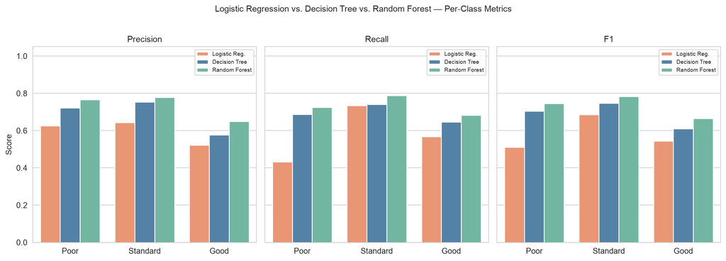

Per-class precision, recall, and F1 for all three classifiers. The random forest leads across most metrics; logistic regression sets the linear baseline.

## Summary Table

- We also summarise the key results in a table comparing validation accuracy, OOB accuracy (for random forest), whether the model has a linear decision boundary, and interpretability.

```python
summary = pd.DataFrame({
    'Model': [
        'Logistic Regression',
        'Decision Tree (depth 8)',
        'Random Forest (200 trees)',
    ],
    'Val. Accuracy': [
        round(accuracy_score(y_val, y_pred_lr), 4),
        round(accuracy_score(y_val, y_pred_dt), 4),
        round(accuracy_score(y_val, y_pred_rf), 4),
    ],
    'OOB Accuracy':   ['—', '—', round(rf.oob_score_, 4)],
    'Linear boundary?': ['Yes', 'No', 'No'],
    'Interpretable?':   ['Coefficients', 'Tree diagram', 'Feature importance only'],
})
print(summary.to_string(index=False))
```

## Summary Table

```
                    Model  Val. Accuracy OOB Accuracy Linear boundary?          Interpretable?
      Logistic Regression         0.6162            —              Yes            Coefficients
  Decision Tree (depth 8)         0.7085            —               No            Tree diagram
Random Forest (200 trees)         0.7510       0.7467               No Feature importance only
```

# Conclusion

## ✅ What We Covered

- **Classification** — predicting a categorical response and how it differs from regression.
- **Logistic regression** — binary sigmoid recap; multinomial extension; linear decision boundaries; applied as our baseline.
- **Decision trees** — recursive binary splitting via Gini impurity; overfitting and depth control; applied and visualized.
- **Random forests** — bagging + feature subsampling to reduce variance; OOB error; feature importance; applied and compared.
- **Evaluation** — confusion matrix, precision, recall, F1, and their multiclass extensions.
- **Three-way comparison** — the Kaggle Credit Score dataset taken from raw data to three fitted classifiers with a head-to-head performance summary.

### 📅 What’s Next?

- **Lecture 17**: Time Series — stationarity, autocorrelation, ARIMA, and forecasting with a real economic dataset.
- **Lectures 18–20**: Unsupervised learning, neural networks, and ethics in data science.